# Assignment-01

Author

Yifan Meng

Published

February 16, 2025

## 1 Question 1 [12pts]

A performance test of manual dexterity was administered to a group of subjects. The frequency distribution is reported as follows.

| Score | 50 | 60 | 70 | 80 | 90 |
| --- | --- | --- | --- | --- | --- |
| Frequency | 1 | 2 | 3 | 3 | 1 |

### 1.1 Part 1 [3pts]

#### 1.1.1 Question

Compute the mean, variance, and standard deviation of the score distribution.

*Hint: You can use mean(), var(), and sd() functions in R.*

#### 1.1.2 Answer

```r
# Create the data
scores <- rep(c(50, 60, 70, 80, 90), times=c(1, 2, 3, 3, 1))

# Calculate statistics
mean(scores)
```

```
[1] 71
```

```r
var(scores)
```

```
[1] 143.3333
```

```r
sd(scores)
```

```
[1] 11.97219
```

```r
sd(scores)/sqrt(length(scores))
```

```
[1] 3.785939
```

```r
## Values of the answer below is calculated by function round(), e.g.: round(sd(scores),2)
```

**Report**

- The mean of this score distribution is 71
- The variance of the score distribution is 143.33
- The standard deviation of the score distribution is 11.97

### 1.2 Part 2 [9pts]

#### 1.2.1 Question

The following table contains raw scores, z-scores, and T-scores for Joan and Peter from the group. Complete the table by finding out the unknown values (a), (b), and (c).

| Name | Raw score | z-score | T-score |
| --- | --- | --- | --- |
| Joan | 80.00 | 0.75 | 57.50 |
| Peter | 49.45 | -1.80 | 32.00 |

#### 1.2.2 Answer

**Solution Process**

According to **Part 1**, $\mu$ estimated by the distribution is 71 and $\sigma$ is 11.97.

##### 1.2.2.1 (a) Joan’s z-score:

$$\begin{aligned}
z &= \frac{X - \mu}{\sigma} \\
z &= \frac{80 - 71}{11.97} = \frac{9}{11.97} \approx 0.75
\end{aligned}$$

##### 1.2.2.2 (b): Peter’s raw score

$$X = z \cdot \sigma + \mu$$

## 2 Question 2 [11pts]

James is interested in finding the relationship between Introversion and Social Dominance. He collected the following data and calculated the descriptive statistics of the data.

| Examinee | 1 | 2 | 3 | 4 | 5 | 6 | 7 | 8 | Mean | SD |
| --- | --- | --- | --- | --- | --- | --- | --- | --- | --- | --- |
| Introversion | 0 | 1 | 1 | 2 | 2 | 3 | 4 | 5 | 2.25 | 1.67 |
| Social Dominance | 4 | 5 | 4 | 2 | 3 | 3 | 2 | 1 | 3.00 | 1.31 |

### 2.1 Part 1 [3pts]

#### 2.1.1 Question

Obtain a scatter plot of the two variables by using plot() function in R. Please put Introversion on the x-axis and Social Dominance on the y-axis.

*Hint: You can construct the dataset in .csv or .txt format and import the data OR you can also create data objects by running the codes below:*

#### 2.1.2 Answer

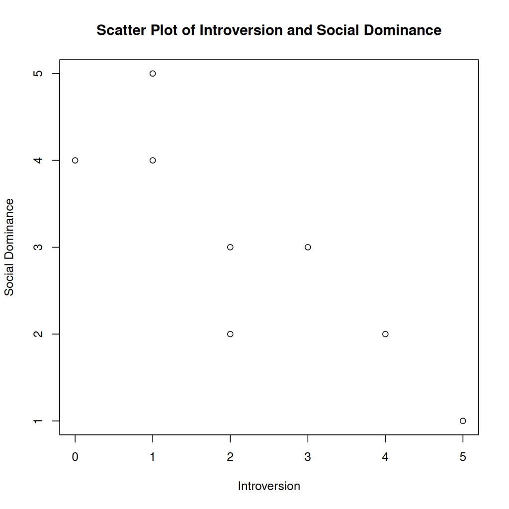

Figure 1

```r
Introv <- c(0, 1, 1, 2, 2, 3, 4, 5)
Socialdom <- c(4, 5, 4, 2, 3, 3, 2, 1)
#df <- data.frame(Introv, Socialdom)

plot(Introv,Socialdom,main = "Scatter Plot of Introversion and Social Dominance",
     xlab = "Introversion", ylab = "Social Dominance")
```

### 2.2 Part 2 [6pts]

#### 2.2.1 Question

Based on the scatter plot you obtained in 2-1), how would you describe the: i) trend ii) strength iii) direction of the association between the two variables? Select your response from the following options for each element:

1. Positive b) Negative
2. Linear d) Non-linear
3. Strong f) Weak

#### 2.2.2 Answer

3. direction: b) Negative
4. strength: e) Strong
5. trend: c) Linear

**Details**

- **Direction (Negative)**: As Introversion increases, Social Dominance tends to decrease.
- **Strength (Strong)**: The points are closely clustered around a downward trend, indicating a strong relationship (also can be supported by the correlation coefficient below).
- **Trend (Linear)**: The pattern follows a straight line rather than a curve.

### 2.3 Part 3 [2pts]

#### 2.3.1 Question

Compute the Pearson correlation coefficient between Introversion and Social Dominance using cor() function in R.

#### 2.3.2 Answer

```r
cor(Introv,Socialdom)
```

```
[1] -0.8498366
```

The Pearson correlation between Introversion and Social Dominance is -0.85

## 3 Question 3 [8pts]

Determine the scale of measurement for each of the following variables.

1. [2pts] Ranking of baseball teams (determined by their won-lost records at the end of the season): **Ordinal Scale**
2. [2pts] Social Security numbers: **Nominal Scale**
3. [2pts] Air distance between New York City and other cities in the United States: **Interval Scale**
4. [2pts] pH value: **Ratio Scale**

## 4 Question 4 [9pts]

The scores of a reference population on the Wechsler Intelligence Scale for Children (WISC) are normally distributed with μ = 100 and σ = 15.

#### 4.0.1 Question 1 [3pts]

Approximately what percentage of the population would score below 100 on the test? **50%**

#### 4.0.2 Answer 1

**Solution**

The WISC scores follow a normal distribution:

$$X \sim \mathcal{N}(100, 15^2)$$

Here we want to estimate
$$P(X < 100)$$
Because $\mu$=100, so z-score of 100 is 0.

From the standard normal table, the probability of a z-score being less than 0 is 50%

Or directly calculate using R

```r
    pnorm(100, mean = 100, sd = 15)
```

```
[1] 0.5
```

#### 4.0.3 Question 2 [3pts]

Approximately what percentage of the population would score above 130 on the test?

#### 4.0.4 Answer 2

The z score of 130 in this test is 2, so there will be approximately 2.5% of the population would score above 130 on the test.

**Solution**

Here we want to estimate:
$$P(X > 130)$$

Then, calculate the z-score for 130:

$$\begin{aligned}
z &= \frac{130 - 100}{15} \\[1em]
z &= \frac{30}{15} = 2
\end{aligned}$$
Based on the standard norm table:

$$P(Z > 2) = 1 - P(Z < 2) \approx 1-0.975 \approx 0.025$$

For z = 2:

- Area above z = 2 ≈ 2.5%
- Therefore, approximately **2.5%** of the population would score above 130

Or directly calculate using R

```r
    1-pnorm(130,mean=100,sd=15)
```

```
[1] 0.02275013
```

```r
    #or
    pnorm(130,mean=100,sd=15,lower.tail = FALSE)
```

```
[1] 0.02275013
```

#### 4.0.5 Question 3 [3pts]

Approximately what percentage of the population would score between 100 and 130 on the test? **47.5%**

#### 4.0.6 Answer 3

**Solution**

Here we want to calculate:
$$P(100<X<130)$$
From 2 subquestions above,

$$\begin{aligned}
P(X < 130) &\approx 0.975\\
P(X > 100)&=0.5
\end{aligned}$$
So:

$$P(100<X<130)=P(X < 130)-P(X > 100)=0.975-0.5=47.5%$$

In R:

```r
    pnorm(130, mean = 100, sd = 15) - pnorm(100, mean = 100, sd = 15)
```

```
[1] 0.4772499
```

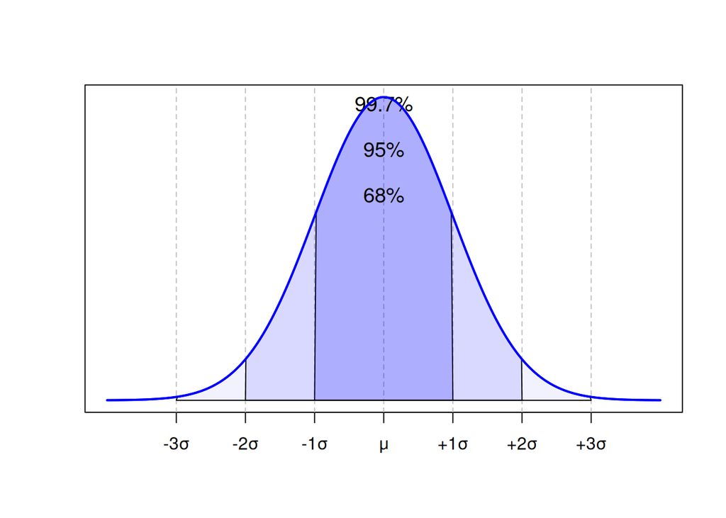

Figure 2